# H1 — Are there two trends in the main scatter?

Quick diagnostic: residual distribution + decade colouring

2026-06-22

## The question

The main scatter plot (log B_obs vs log B_pred) looked as though it might contain **two separate trends** rather than one diffuse cloud. This document checks:

1. **Is the residual distribution unimodal or bimodal?** — a true second group would leave a second peak in the residuals.
2. **Do the apparent trends separate by decade?** — whether any temporal structure is present in the haul-level residuals.

Overall log_r2 across all 12,069 hauls: **-0.223**. Negative = EEoS overpredicts on average.

## 1. Residual distribution — one failure mode or two?

A negative residual means EEoS overpredicts (log B_pred > log B_obs). The median residual is **-1.406** log-units (≈ 4.1× overprediction on the raw scale). If the distribution has a single peak, the “two trends” appearance is a density artifact from overplotting. A shoulder or second peak means a real subpopulation behaves differently.

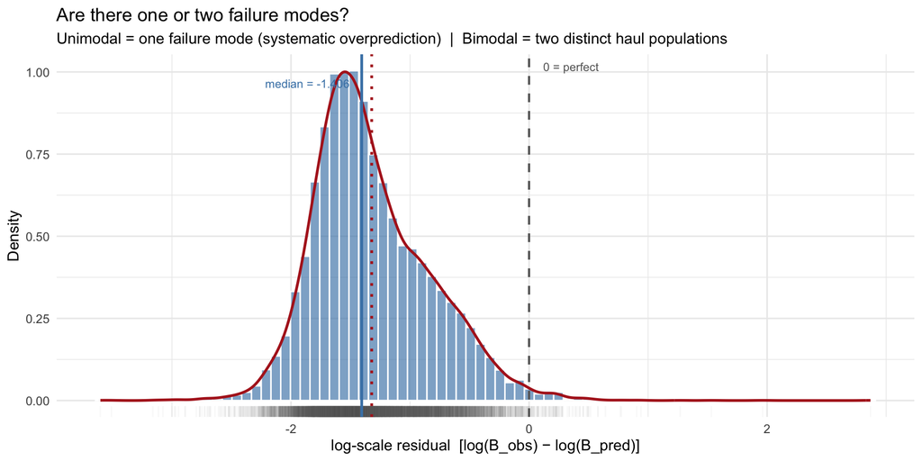

EEoS log-scale residuals. Blue vertical line = median; red dotted = mean. Negative = EEoS overpredicts. The rug along the bottom shows every individual haul.

## 2. Main scatter coloured by decade

If any temporal structure exists in the haul-level residuals, it should be visible as a separation of decade colours within the cloud. Decades well-mixed throughout the cloud indicate no temporal structure at this scale — any such structure, if it exists, would need to emerge at aggregated spatial or temporal scales (H2, H3).

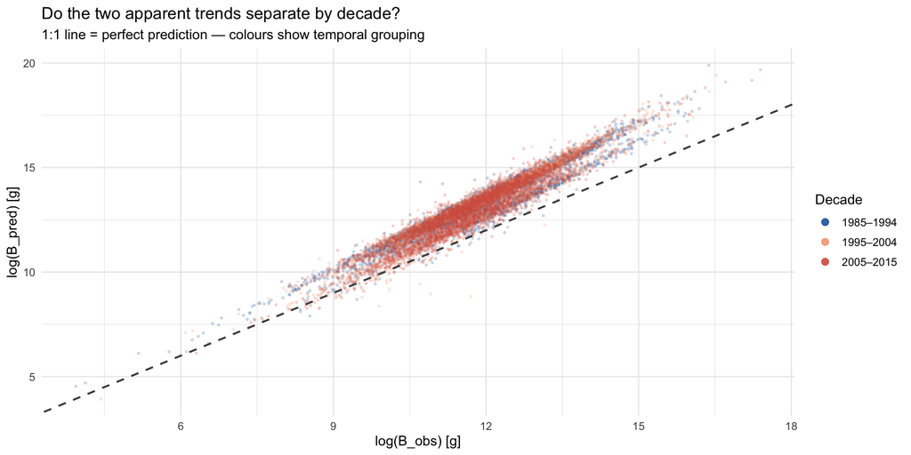

**Supplementary Figure S2.** log(B_obs) vs log(B_pred) coloured by decade. Decades are well-mixed throughout the cloud with no systematic temporal separation at haul level. Whether residuals carry temporal structure at aggregated spatial scales is addressed in H2 and H3.

## 3. Per-decade summary table

EEoS performance by decade — does the failure mode change over time?

| Decade | n hauls | log_r2 | Median log residual | Median B_pred/B_obs |
| --- | --- | --- | --- | --- |
| 1985–1994 | 4049 | -0.172 | -1.439 | 4.2 |
| 1995–2004 | 3822 | -0.328 | -1.488 | 4.4 |
| 2005–2015 | 4198 | -0.215 | -1.296 | 3.7 |

## 4. What to take from this

**Residual density (Figure S1):** Unimodal — a single, consistent failure mode. EEoS overpredicts with a roughly log-normal spread. There is no genuine second population of hauls with near-accurate prediction.

**Decade colouring (Figure S2):** Decades are well-mixed throughout the cloud. There is no systematic temporal separation at haul level. Whether aggregated spatial-temporal structure exists in EEoS residuals is the question H2 and H3 address.